# Time Series Final Project

Greg Platt

April 28, 2019

## Data Source Selected

I opted to use the Econ5 Data (econ5)

This data examines several key quarterly US economic metrics over a period of 40 years. I opted to treat private investment as the dependant variable of the data set. The actual data isn’t clear if it is, but as is discovered below, there do a strong job of predicting its behavior. I am also personally interested in these metrics as they apply to my work in predicting work volumes for my employer as they relate to macro economic variables, so this work is immediately reusable. For privacy reasons, I opted not to include the work volumes in my submitted version of the assignment.

```r
library(astsa)
data = astsa::econ5
time_series = ts(data, start = 1948.5, frequency = 4)
```

## Summary Statistics

The units for each variable are different, but for the predicted variable ‘prinv’. The measurement units are not identifed but seem to be in billions of dollars.

Below, several summarized statistics for the data are provided.

```r
summary(data)
```

```
##      unemp             gnp           consum           govinv
##  Min.   : 2.600   Min.   :1103   Min.   : 681.4   Min.   :178.7
##  1st Qu.: 4.200   1st Qu.:1553   1st Qu.: 926.0   1st Qu.:396.7
##  Median : 5.700   Median :2367   Median :1396.7   Median :564.0
##  Mean   : 5.683   Mean   :2340   Mean   :1447.5   Mean   :499.7
##  3rd Qu.: 6.900   3rd Qu.:3116   3rd Qu.:1960.8   3rd Qu.:596.0
##  Max.   :10.400   Max.   :4011   Max.   :2586.8   Max.   :776.6
##      prinv
##  Min.   :160.2
##  1st Qu.:258.3
##  Median :387.7
##  Mean   :392.9
##  3rd Qu.:511.4
##  Max.   :721.1
```

```r
max(data$prinv)
```

```
## [1] 721.1
```

```r
min(data$prinv)
```

```
## [1] 160.2
```

```r
mean(data$prinv)
```

```
## [1] 392.8807
```

```r
sd(data$prinv)
```

```
## [1] 148.7499
```

```r
start(time_series)
```

```
## [1] 1948    3
```

```r
end(time_series)
```

```
## [1] 1988    3
```

```r
frequency(time_series)
```

```
## [1] 4
```

## Data Exploration

The boxplots suggest that private investment doesn’t vary significantly on a quarterly basis, which makes sense as the driving econimic metrics tend to be persistant without demonstrating much seasonal variation. In recent years, unemployment has typically dropped in Q4 due to holiday hiring, but this trend does not seem to exist during the time frame of this data, or if it does, its temporary nature doesn’t impact private investment.

The second chart demonstrates how private investment trends over the course of the data. You will observe a positive movement over time.

To detrend the data, we first take the log of the series, in order to help reduce the variance over time. Then, a lag 4 difference is applied, to correct for any slight quarterly trend which may exist. Last, we take that differenced data and arrive at an approximately stationary dataset.

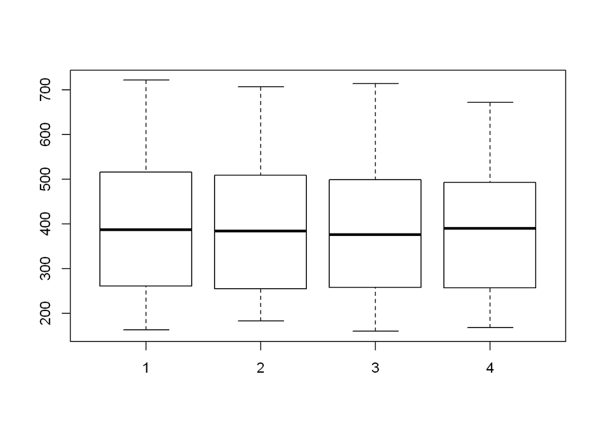

```r
boxplot(time_series[,'prinv']~cycle(time_series[,'prinv']))
```

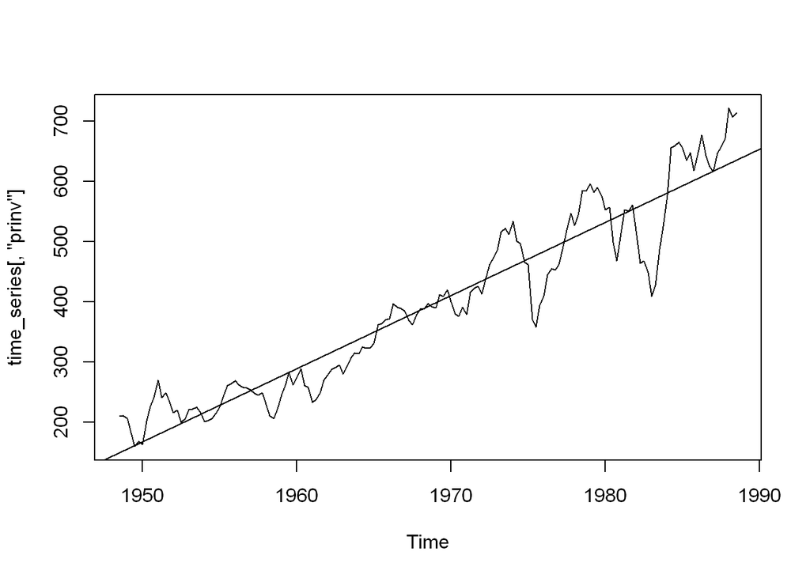

```r
plot(time_series[,'prinv'])
abline(reg=lm(time_series[,'prinv']~time(time_series[,'prinv'])))
```

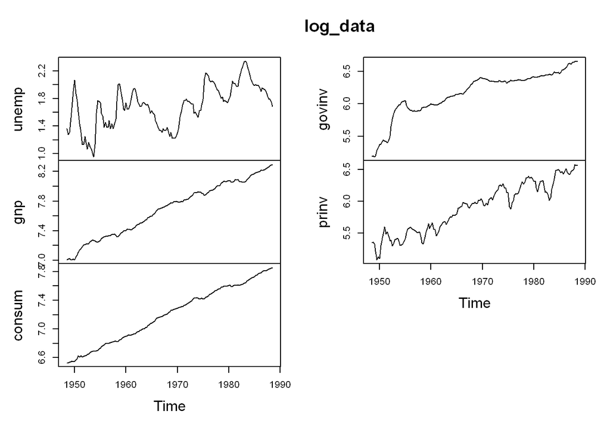

```r
log_data <- log(time_series)
plot(log_data)
```

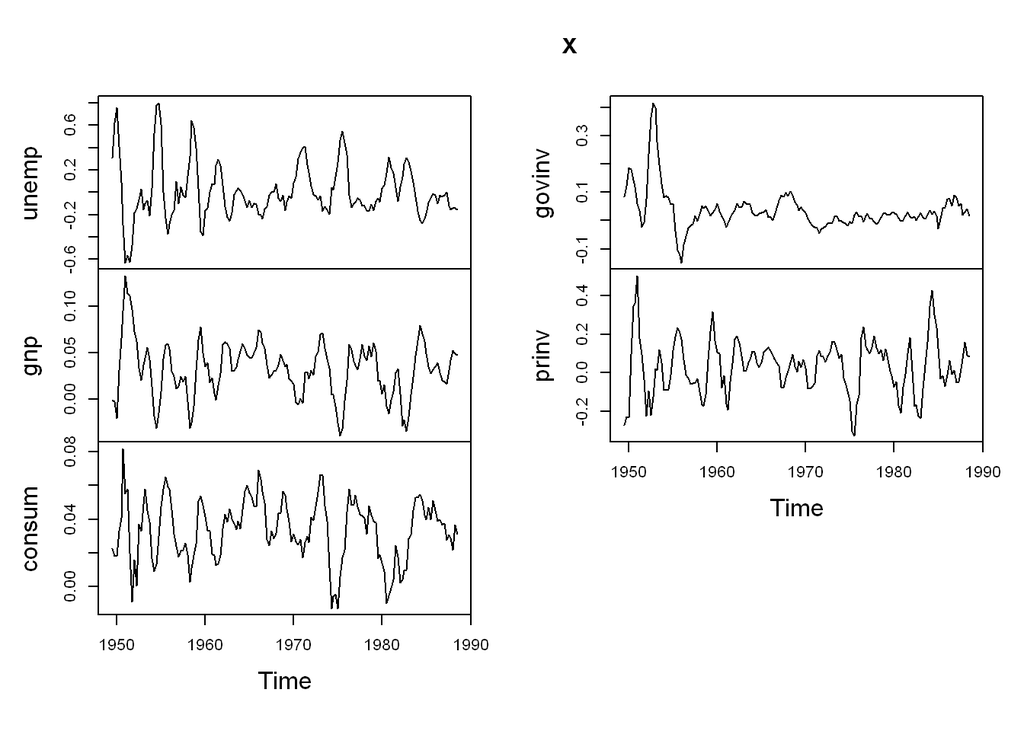

```r
x <- diff(log_data, lag = 4)
plot(x)
```

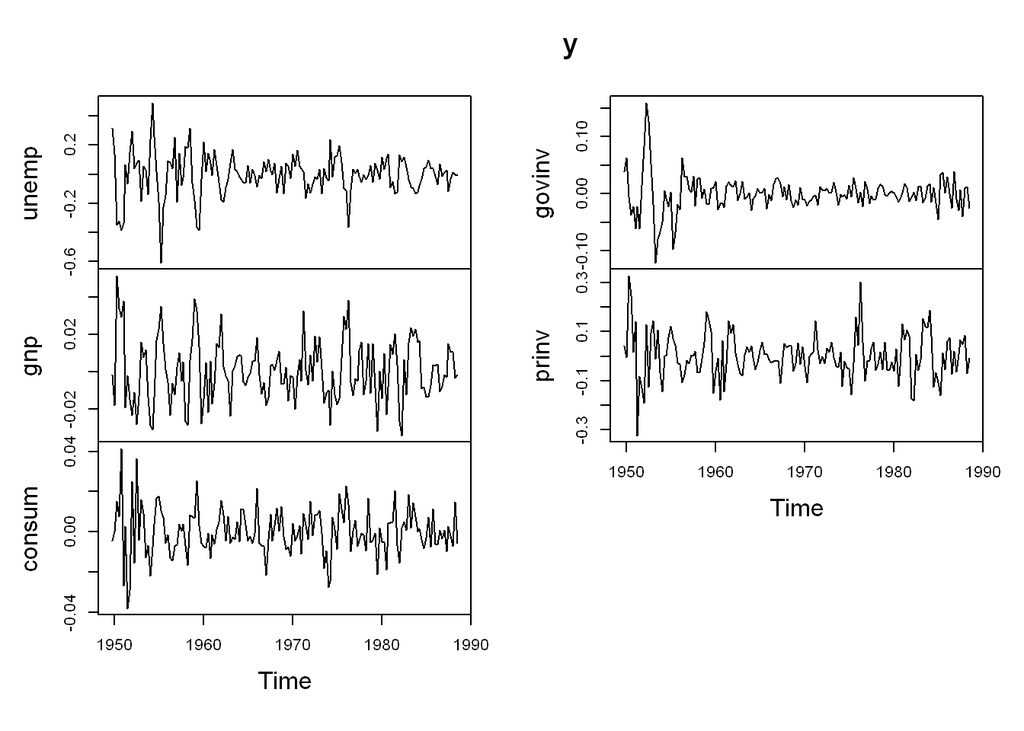

```r
y <- diff(x)
plot(y)
```

## Data Decomposition

The decomposition of the model suggests an additive trend, that does exhibit a minor cyclical seasonal pattern. The data also exhibits a fair amount of randomness during the latter portion of the time series.

```r
decompose(time_series[,'prinv'])
```

```
## $x
##       Qtr1  Qtr2  Qtr3  Qtr4
## 1948             210.3 211.5
## 1949 206.0 183.2 160.2 168.3
## 1950 163.4 201.9 226.1 241.6
## 1951 270.3 241.6 249.0 233.8
## 1952 216.2 219.9 199.9 206.6
## 1953 220.8 222.3 225.1 217.4
## 1954 201.5 203.2 206.4 215.0
## 1955 225.7 245.1 260.8 264.3
## 1956 268.9 262.1 258.3 257.1
## 1957 253.8 248.6 245.3 249.2
## 1958 230.3 210.9 206.2 222.2
## 1959 246.4 261.7 283.1 262.4
## 1960 274.1 288.7 261.4 258.3
```

[output cut: 169 more lines]

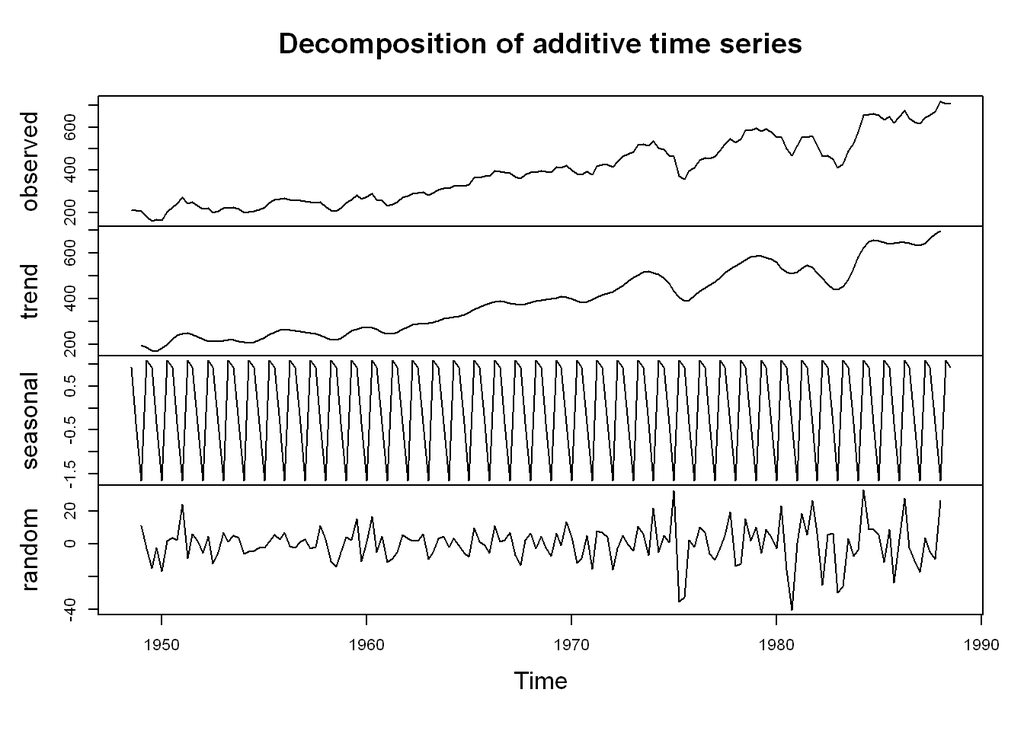

```r
plot(decompose(time_series[,'prinv']))
```

## Regression

For linear regression, I first tested a model using all variables, while it had an extremely high adj. r-squared value, the summary indicated that the consumption variable didn’t add value to the model. A second with that variable removed showed a near identical adj r-squared, and also had improved AIC and BIC values indicating that it was a more useful model.

```r
linearMod <- lm(prinv ~ unemp + gnp + consum + govinv, data=time_series)
summary(linearMod)
```

```
##
## Call:
## lm(formula = prinv ~ unemp + gnp + consum + govinv, data = time_series)
##
## Residuals:
##    Min     1Q Median     3Q    Max
## -73.12 -14.41  -0.89  18.27  66.99
##
## Coefficients:
##              Estimate Std. Error t value Pr(>|t|)
## (Intercept)  43.93043   14.62246   3.004   0.0031 **
## unemp       -14.04214    1.77722  -7.901 4.65e-13 ***
## gnp           0.30032    0.05163   5.816 3.30e-08 ***
## consum       -0.06888    0.07193  -0.958   0.3397
## govinv       -0.34849    0.04860  -7.171 2.81e-11 ***
## ---
## Signif. codes:  0 '***' 0.001 '**' 0.01 '*' 0.05 '.' 0.1 ' ' 1
##
## Residual standard error: 24.78 on 156 degrees of freedom
## Multiple R-squared:  0.9729, Adjusted R-squared:  0.9723
## F-statistic:  1402 on 4 and 156 DF,  p-value: < 2.2e-16
```

```r
linearMod2 <- lm(prinv ~ unemp + gnp + govinv, data=time_series)
summary(linearMod2)
```

```
##
## Call:
## lm(formula = prinv ~ unemp + gnp + govinv, data = time_series)
##
## Residuals:
##     Min      1Q  Median      3Q     Max
## -74.346 -15.493  -1.101  18.928  68.261
##
## Coefficients:
##               Estimate Std. Error t value Pr(>|t|)
## (Intercept)  54.841759   9.161687   5.986 1.41e-08 ***
## unemp       -15.056833   1.426396 -10.556  < 2e-16 ***
## gnp           0.251536   0.008402  29.936  < 2e-16 ***
## govinv       -0.329900   0.044542  -7.407 7.46e-12 ***
## ---
## Signif. codes:  0 '***' 0.001 '**' 0.01 '*' 0.05 '.' 0.1 ' ' 1
##
## Residual standard error: 24.77 on 157 degrees of freedom
## Multiple R-squared:  0.9728, Adjusted R-squared:  0.9723
## F-statistic:  1871 on 3 and 157 DF,  p-value: < 2.2e-16
```

```r
AIC(linearMod)
```

```
## [1] 1497.437
```

```r
BIC(linearMod)
```

```
## [1] 1515.926
```

```r
AIC(linearMod2)
```

```
## [1] 1496.381
```

```r
BIC(linearMod2)
```

```
## [1] 1511.788
```

## ARMA Modeling

The ACF and PACF plots suggest that the ACF trails off and the PACF cuts off after 1 lag. This would suggest some an AR model is best, likely an AR(1)

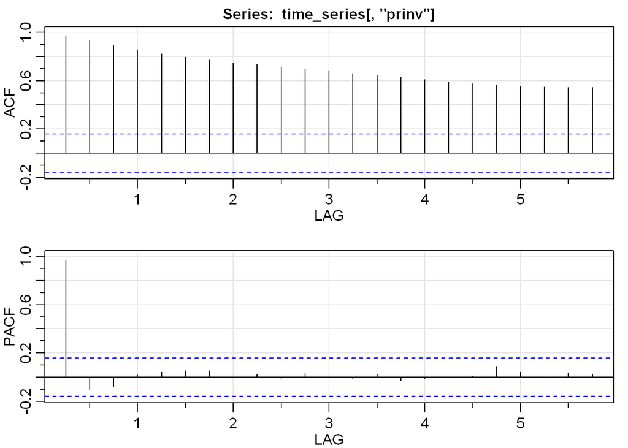

```
##        ACF  PACF
##  [1,] 0.97  0.97
##  [2,] 0.93 -0.10
##  [3,] 0.89 -0.08
##  [4,] 0.86  0.02
##  [5,] 0.82  0.04
##  [6,] 0.80  0.05
##  [7,] 0.77  0.06
##  [8,] 0.75  0.00
##  [9,] 0.73  0.03
## [10,] 0.71 -0.02
## [11,] 0.70  0.03
## [12,] 0.68  0.00
## [13,] 0.66 -0.01
## [14,] 0.65  0.02
## [15,] 0.63 -0.03
## [16,] 0.61 -0.01
## [17,] 0.59  0.00
## [18,] 0.58  0.01
## [19,] 0.56  0.09
## [20,] 0.56  0.04
## [21,] 0.55  0.00
## [22,] 0.55  0.03
## [23,] 0.54  0.03
```

```r
acf2(time_series[,'prinv'])
```

## Model Diagnostics

After trying several different ARIMA models, it appears that an AR(2) does the best job of fitting the data. The AR(1) suggested from the plots above left a few ACF residuals above the threshold and p values were all below 0 in the Ljung-Box. A change to AR(2) corrected all of these. The ARMA(1,1) also fit well, but overall the statistics suggest that the AR(2) is a better choice for this data.

```r
is_ar_model <- sarima(time_series[,'prinv'],2,0,0)
```

[figure not shown]

```r
is_ma_model <- sarima(time_series[,'prinv'],0,0,1)
```

[figure not shown]

```r
is_arma_model <- sarima(time_series[,'prinv'],1,0,1)
```

[figure not shown]